# CA4

## Random Forest Classifier

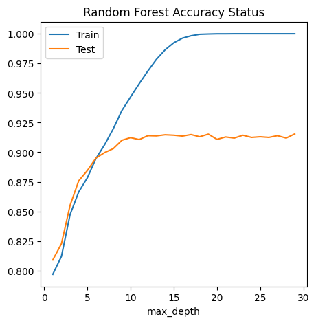

```python
from sklearn.ensemble import RandomForestClassifier
from mlxtend.evaluate import bias_variance_decomp

def plot_random_forest_model(depth_range_max):
    depths = range(1, depth_range_max)

    test_accuracy  = []
    train_accuracy = []

    for depth in depths:
        forest = RandomForestClassifier(max_depth=depth)
        forest.fit(data_train, label_train_lv)

        train_prediction = forest.predict(data_train)
        train_accuracy.append(accuracy_score(label_train_lv, train_prediction))

        test_prediction = forest.predict(data_test)
        test_accuracy.append(accuracy_score(label_test_lv, test_prediction))

    plt.figure(figsize=(5, 5))
    plt.plot(depths, train_accuracy, label='Train')
    plt.plot(depths, test_accuracy, label='Test')
    plt.xlabel('max_depth')
    plt.legend()
    plt.title('Random Forest Accuracy Status')
    plt.show()

plot_random_forest_model(30)
```

```python
# forest = RandomForestClassifier(max_depth=11)
# forest.fit(data_train, label_train_lv)
# label_test_decomp = copy.deepcopy(label_test_lv)
# label_train_decomp = copy.deepcopy(label_train_lv)

# for i, v in label_train_lv.items() :
#     if(v == "HIGH"):
#         label_train_decomp[i] = 1
#     else:
#         label_train_decomp[i] = 0

# for i, v in label_test_lv.items() :
#     if(v == "HIGH"):
#         label_test_decomp[i] = 1
#     else:
#         label_test_decomp[i] = 0

# mse, bias, variance = bias_variance_decomp(forest, data_train.values, label_train_decomp.values,
#                                       data_test.values, label_test_decomp.values, loss='mse', num_rounds=100)

# print(f"Bias is : {bias}\nVariance is : {variance}")
```

```python
forest = RandomForestClassifier(max_depth=11)
forest.fit(data_train, label_train_lv)

train_prediction = forest.predict(data_train)
train_accuracy.append(accuracy_score(label_train_lv, train_prediction))

test_prediction = forest.predict(data_test)
test_accuracy.append(accuracy_score(label_test_lv, test_prediction))

accuracy_test   =  accuracy_score(label_test_lv, test_prediction)
precision_test  =  precision_score(label_test_lv, test_prediction, pos_label='LOW')
recall_test     =  recall_score(label_test_lv, test_prediction, pos_label='LOW')

accuracy_train  =  accuracy_score(label_train_lv, train_prediction)
precision_train =  precision_score(label_train_lv, train_prediction, pos_label='LOW')
recall_train    =  recall_score(label_train_lv, train_prediction, pos_label='LOW')

print('for training data : ')
print('accuracy:', accuracy_train, 'precision:', precision_train, 'recall:', recall_train)
print('for testing data : ')
print('accuracy:', accuracy_test, 'precision:', precision_test, 'recall:', recall_test)
```

```
for training data :
accuracy: 0.9586649392312913 precision: 0.9607674332800393 recall: 0.9570011025358324
for testing data :
accuracy: 0.9126572908956329 precision: 0.9054545454545454 recall: 0.921539600296077
```

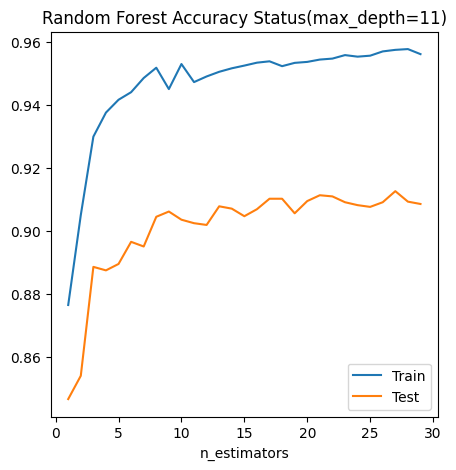

```python
def plot_random_forest_model_n_est(estimator_range_max):
    estimators = range(1, estimator_range_max)

    test_accuracy  = []
    train_accuracy = []

    for estimator in estimators:
        forest = RandomForestClassifier(max_depth=11, n_estimators=estimator)
        forest.fit(data_train, label_train_lv)

        train_prediction = forest.predict(data_train)
        train_accuracy.append(accuracy_score(label_train_lv, train_prediction))

        test_prediction = forest.predict(data_test)
        test_accuracy.append(accuracy_score(label_test_lv, test_prediction))

    plt.figure(figsize=(5, 5))
    plt.plot(estimators, train_accuracy, label='Train')
    plt.plot(estimators, test_accuracy, label='Test')
    plt.xlabel('n_estimators')
    plt.legend()
    plt.title('Random Forest Accuracy Status(max_depth=11)')
    plt.show()

plot_random_forest_model_n_est(30)
```

Choosing n_estimators=22 will help us avoid overfitting/underfitting.  
Now let's go for 'min_sample_leaf'

```python
forest = RandomForestClassifier(max_depth=11, n_estimators=22)
forest.fit(data_train, label_train_lv)

train_prediction = forest.predict(data_train)
train_accuracy.append(accuracy_score(label_train_lv, train_prediction))

test_prediction = forest.predict(data_test)
test_accuracy.append(accuracy_score(label_test_lv, test_prediction))

accuracy_test   =  accuracy_score(label_test_lv, test_prediction)
precision_test  =  precision_score(label_test_lv, test_prediction, pos_label='LOW')
recall_test     =  recall_score(label_test_lv, test_prediction, pos_label='LOW')

accuracy_train  =  accuracy_score(label_train_lv, train_prediction)
precision_train =  precision_score(label_train_lv, train_prediction, pos_label='LOW')
recall_train    =  recall_score(label_train_lv, train_prediction, pos_label='LOW')

print('for training data : ')
print('accuracy:', accuracy_train, 'precision:', precision_train, 'recall:', recall_train)
print('for testing data : ')
print('accuracy:', accuracy_test, 'precision:', precision_test, 'recall:', recall_test)
```

```
for training data :
accuracy: 0.9571225862175334 precision: 0.9596258000984736 recall: 0.9550410388337621
for testing data :
accuracy: 0.9106217616580311 precision: 0.905074844833881 recall: 0.9174685418208735
```

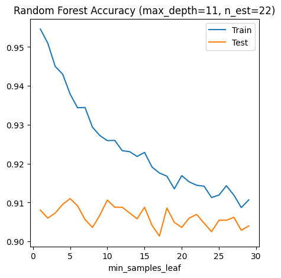

```python
def plot_random_forest_model_MSL(min_sample_leaf_range_max):
    leaves = range(1, min_sample_leaf_range_max)

    test_accuracy  = []
    train_accuracy = []

    for leaf in leaves:
        forest = RandomForestClassifier(max_depth=11, n_estimators=22, min_samples_leaf=leaf)
        forest.fit(data_train, label_train_lv)

        train_prediction = forest.predict(data_train)
        train_accuracy.append(accuracy_score(label_train_lv, train_prediction))

        test_prediction = forest.predict(data_test)
        test_accuracy.append(accuracy_score(label_test_lv, test_prediction))

    plt.figure(figsize=(5, 5))
    plt.plot(leaves, train_accuracy, label='Train')
    plt.plot(leaves, test_accuracy, label='Test')
    plt.xlabel('min_samples_leaf')
    plt.legend()
    plt.title('Random Forest Accuracy (max_depth=11, n_est=22)')
    plt.show()

plot_random_forest_model_MSL(30)
```

choosing min_samples_leaf=8 will help us avoid overfitting/underfitting

```python
forest = RandomForestClassifier(max_depth=11, n_estimators=22, min_samples_leaf=8)
forest.fit(data_train, label_train_lv)

train_prediction = forest.predict(data_train)
train_accuracy.append(accuracy_score(label_train_lv, train_prediction))

test_prediction = forest.predict(data_test)
test_accuracy.append(accuracy_score(label_test_lv, test_prediction))

accuracy_test   =  accuracy_score(label_test_lv, test_prediction)
precision_test  =  precision_score(label_test_lv, test_prediction, pos_label='LOW')
recall_test     =  recall_score(label_test_lv, test_prediction, pos_label='LOW')

accuracy_train  =  accuracy_score(label_train_lv, train_prediction)
precision_train =  precision_score(label_train_lv, train_prediction, pos_label='LOW')
recall_train    =  recall_score(label_train_lv, train_prediction, pos_label='LOW')

print('for training data : ')
print('accuracy:', accuracy_train, 'precision:', precision_train, 'recall:', recall_train)
print('for testing data : ')
print('accuracy:', accuracy_test, 'precision:', precision_test, 'recall:', recall_test)
```

```
for training data :
accuracy: 0.9312110555864026 precision: 0.9340970682434097 recall: 0.928947690799951
for testing data :
accuracy: 0.905440414507772 precision: 0.9037965352008847 recall: 0.9074759437453738
```

## q2

As we know, bias is bias in favor or against a certain result. The less bias our model has, the more acceptable it is. In fact, bias is more related to the accuracy of the training data prediction, and the higher the accuracy of the training data, the lower the bias.  
Variance is more related to the difference between training and test data accuracy. If the difference between the accuracy of the training and test data is large, there is also (a large) variance.  
The relationship between variance and bias is inverse, that is, the higher the variance, the lower the bias and vice versa. According to these explanations, we are looking for a model that has a balance between these two variables and generally has less bias and variance.  
In general, both Decision Tree and Random Forest models are Low Bias and High Variance, but the variance of the Random Forest model is less than It is a decision tree model. Considering that the Random Forest model uses several trees for prediction, we expect a better result. In this model, the amount of variance is reduced, but the amount of bias may be increased bu generally saying it has served our interest in some parameters while not in other ones.

# Gradient boosting

## q1

Gradient boosting is one of the variants of ensemble methods where you create multiple weak models and combine them to get better performance.  
Gradient boosting is a machine learning technique used in regression and classification tasks.  
It gives a prediction model in the form of an ensemble of weak prediction models, which are typically decision trees.  
It usually outperforms algorithms like decision tree or random forest.  
It's a form of boosting method in which combines weak "learners" into a single strong learner in an iterative fashion. (a linear combination of some weak models to create a strong one)  
It is easiest to explain in the least-squares regression setting, where the goal is to "teach" a model F to predict values of the form y = F(x) by minimizing the mean squared error

## q2

XGBoost stands for Extreme Gradient Boosting.  
XGBoost is a more regularized form of Gradient Boosting. XGBoost uses advanced regularization (L1 & L2), which improves model generalization capabilities. XGBoost delivers high performance as compared to Gradient Boosting. Its training is very fast.  
It provides parallel tree boosting and is a leading machine learning library for regression, classification.  
XGBoost works as Newton-Raphson in function space unlike gradient boosting that works as gradient descent in function space.  
It has some feautues like :

- Clever penalization of trees
- A proportional shrinking of leaf nodes
- Newton Boosting
- Extra randomization parameter
- Tree pruning

## q3

```python
from xgboost import XGBClassifier

label_test_decomp = copy.deepcopy(label_test_lv)
label_train_decomp = copy.deepcopy(label_train_lv)

for i, v in label_train_lv.items() :
    if(v == "HIGH"):
        label_train_decomp[i] = 1
    else:
        label_train_decomp[i] = 0

for i, v in label_test_lv.items() :
    if(v == "HIGH"):
        label_test_decomp[i] = 1
    else:
        label_test_decomp[i] = 0

def plot_XGBOOST_model(max_depth_range_max):
    depths = range(1, max_depth_range_max)

    test_accuracy  = []
    train_accuracy = []

    for depth in depths:
        xgb = XGBClassifier(max_depth=depth)
        xgb.fit(data_train, label_train_decomp)

        train_prediction = xgb.predict(data_train)
#         train_accuracy.append(accuracy_score(label_train_decomp, train_prediction))

        test_prediction = xgb.predict(data_test)
#         test_accuracy.append(accuracy_score(label_test_decomp, test_prediction))

#     plt.figure(figsize=(5, 5))
#     plt.plot(depths, train_accuracy, label='Train')
#     plt.plot(depths, test_accuracy, label='Test')
#     plt.xlabel('max_depth')
#     plt.legend()
#     plt.title('XGBoost Accuracy Status')
#     plt.show()

plot_XGBOOST_model(20)
```